# STATS 32 Session 2: Packages and Data Frames

# List of useful packages

- `dplyr`: Transform data
- `ggplot2`: Make nice plots
- `readr`: Import data into R
- `tidyr`: Clean data
- `stringr`: Tools for working with character strings and regular expressions
- `lubridate`: Make working with dates and times easier
- `caret`: Tools for training regression and classification models
- `glmnet`: Advanced regression methods
- `maps`, `ggmap`: Tools for plotting spatial data
- `shiny`: Make interactive web apps

# `fueleconomy`: Package information on [CRAN](https://CRAN.R-project.org/)

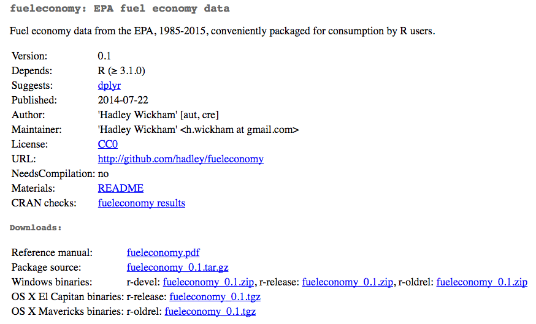

# Measures of central tendency

- **Mean**: sum of all values divided by the number of values
- **Mode**: most commonly occuring value
- **$x$th percentile**: value such that $x$% of the values fall below it
  - **Median**: 50th percentile
  - **1st quartile**: 25th percentile
  - **3rd quartile**: 75th percentile

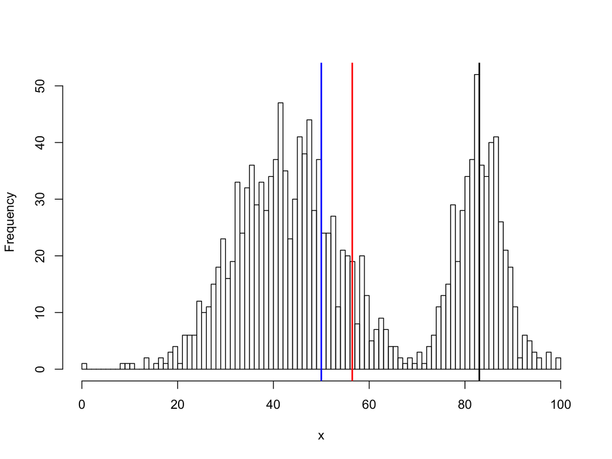

# Measures of spread

- **Variance**: average squared deviation from the mean
- **Standard deviation**: square root of variance
- **Interquartile range**: 3rd quartile - 1st quartile